# Problema 3: Teorema del Límite Central

Simulación, Estimación e Inferencia Estadística · 2026-A

Integrantes: Juan Alejandro Carrillo Jaimes & David Burgoa

2026-03-22

# 1 Descripción del Problema

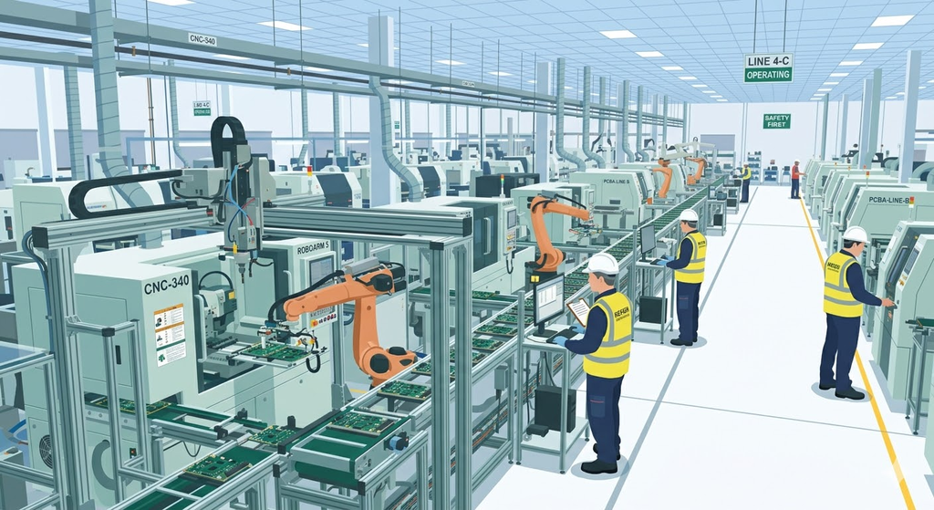

Figure 1.1: Planta de fabricación de componentes electrónicos

En una planta de fabricación de componentes electrónicos, se modela el tiempo (en meses) de funcionamiento continuo de una máquina antes de necesitar mantenimiento mediante una distribución Exponencial. El análisis ha determinado que el tiempo hasta el primer mantenimiento sigue una distribución Exponencial con parámetro $\lambda = 0.16$.

## 1.1 Media y varianza de la población

Para una variable aleatoria $X \sim \text{Exp}(\lambda)$, la media y varianza poblacionales se obtienen directamente de las fórmulas teóricas de la distribución:

$$\mu = \frac{1}{\lambda} \qquad \sigma^2 = \frac{1}{\lambda^2}$$

```r
lambda    <- 0.16
mu_pob    <- 1 / lambda
var_pob   <- 1 / lambda^2
sigma_pob <- sqrt(var_pob)
cv_pob    <- sigma_pob / mu_pob * 100

cat("Media (μ)             :", mu_pob,    "meses\n")
```

```
## Media (μ)             : 6.25 meses
```

```r
cat("Varianza (σ²)         :", var_pob,   "meses²\n")
```

```
## Varianza (σ²)         : 39.0625 meses²
```

```r
cat("Desv. estándar (σ)    :", sigma_pob, "meses\n")
```

```
## Desv. estándar (σ)    : 6.25 meses
```

```r
cat("Coef. de variación (%):", cv_pob,    "%\n")
```

```
## Coef. de variación (%): 100 %
```

Con $\lambda = 0.16$, se obtiene una media de **6.25 meses** y una varianza de **39.06 meses²**. Esto indica que, en promedio, una máquina funciona 6.25 meses antes de necesitar mantenimiento, pero con una dispersión muy alta (σ = 6.25 meses, CV = 100%), lo que es característico de la distribución exponencial y refleja que los tiempos de falla son muy variables entre máquinas.

## 1.2 Gráfico de la curva de densidad

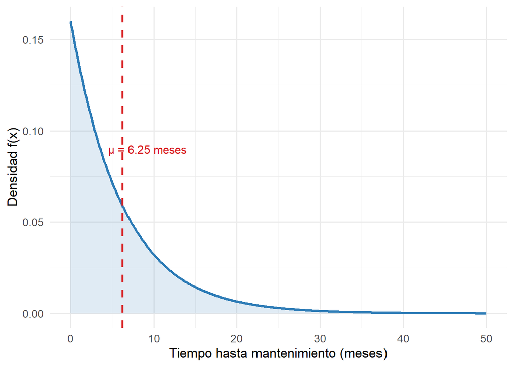

Figure 1.2: Función de densidad — Exp(λ = 0.16)

```r
library(ggplot2)

x_vals <- seq(0, 50, by = 0.1)
df_dens <- data.frame(
  x  = x_vals,
  fx = dexp(x_vals, rate = lambda)
)

ggplot(df_dens, aes(x = x, y = fx)) +
  geom_line(color = "#2c7bb6", linewidth = 1.2) +
  geom_area(alpha = 0.15, fill = "#2c7bb6") +
  geom_vline(xintercept = mu_pob, linetype = "dashed",
             color = "#d7191c", linewidth = 0.9) +
  annotate("text", x = mu_pob + 3, y = 0.09,
           label = paste0("μ = ", mu_pob, " meses"),
           color = "#d7191c", size = 4) +
  labs(
    x = "Tiempo hasta mantenimiento (meses)",
    y = "Densidad f(x)"
  ) +
  theme_minimal(base_size = 13)
```

La Figura 1 muestra una curva decreciente que inicia en $f(0) = \lambda = 0.16$ y se aproxima a cero a medida que aumenta el tiempo. Esto indica que las fallas tempranas son más probables que las tardías. La línea roja marca la media poblacional ($\mu = 6.25$ meses), y se observa que la mayor parte del área queda a la izquierda de ese valor, lo que confirma la asimetría positiva de la distribución.

Un $\lambda$ más grande haría la curva más empinada (fallas más frecuentes y tempranas), mientras que un $\lambda$ más pequeño la aplanaría (máquinas más duraderas). En el contexto del mantenimiento predictivo, este modelo sugiere que la probabilidad de falla es mayor en los primeros meses de operación y disminuye con el tiempo, aunque nunca desaparece completamente.